# Risk Factor Analysis

## Outcome Variable

**Outcome Variable:** haz

## Predictor Variables

**Intervention Variable:** mwtkg

**Adjustment Set:**

- arm
- W_mage
- meducyrs
- feducyrs
- hhwealth_quart
- single
- brthmon
- W_parity
- impfloor
- impsan
- safeh20
- W_gagebrth
- W_birthwt
- W_birthlen
- vagbrth
- parity
- delta_W_mage
- delta_meducyrs
- delta_feducyrs
- delta_hhwealth_quart
- delta_single
- delta_brthmon
- delta_W_parity
- delta_impfloor
- delta_impsan
- delta_safeh20
- delta_W_gagebrth
- delta_W_birthwt
- delta_W_birthlen
- delta_vagbrth
- delta_parity

## Stratifying Variables

The analysis was stratified on these variable(s):

- agecat
- studyid
- country

## Data Summary

| agecat | studyid | country | mwtkg | n_cell | n | outcome_variable |
| --- | --- | --- | --- | --- | --- | --- |
| 6 months | ki0047075b-MAL-ED | BANGLADESH | >=58 kg | 46 | 241 | haz |
| 6 months | ki0047075b-MAL-ED | BANGLADESH | <52 kg | 154 | 241 | haz |
| 6 months | ki0047075b-MAL-ED | BANGLADESH | [52-58) kg | 41 | 241 | haz |
| 6 months | ki0047075b-MAL-ED | BRAZIL | >=58 kg | 137 | 208 | haz |
| 6 months | ki0047075b-MAL-ED | BRAZIL | <52 kg | 37 | 208 | haz |
| 6 months | ki0047075b-MAL-ED | BRAZIL | [52-58) kg | 34 | 208 | haz |
| 6 months | ki0047075b-MAL-ED | INDIA | >=58 kg | 40 | 235 | haz |
| 6 months | ki0047075b-MAL-ED | INDIA | <52 kg | 146 | 235 | haz |
| 6 months | ki0047075b-MAL-ED | INDIA | [52-58) kg | 49 | 235 | haz |
| 6 months | ki0047075b-MAL-ED | NEPAL | >=58 kg | 79 | 236 | haz |
| 6 months | ki0047075b-MAL-ED | NEPAL | <52 kg | 75 | 236 | haz |
| 6 months | ki0047075b-MAL-ED | NEPAL | [52-58) kg | 82 | 236 | haz |
| 6 months | ki0047075b-MAL-ED | PERU | >=58 kg | 100 | 272 | haz |
| 6 months | ki0047075b-MAL-ED | PERU | <52 kg | 107 | 272 | haz |
| 6 months | ki0047075b-MAL-ED | PERU | [52-58) kg | 65 | 272 | haz |
| 6 months | ki0047075b-MAL-ED | SOUTH AFRICA | >=58 kg | 179 | 249 | haz |
| 6 months | ki0047075b-MAL-ED | SOUTH AFRICA | <52 kg | 29 | 249 | haz |
| 6 months | ki0047075b-MAL-ED | SOUTH AFRICA | [52-58) kg | 41 | 249 | haz |
| 6 months | ki0047075b-MAL-ED | TANZANIA, UNITED REPUBLIC OF | >=58 kg | 94 | 247 | haz |
| 6 months | ki0047075b-MAL-ED | TANZANIA, UNITED REPUBLIC OF | <52 kg | 95 | 247 | haz |
| 6 months | ki0047075b-MAL-ED | TANZANIA, UNITED REPUBLIC OF | [52-58) kg | 58 | 247 | haz |
| 6 months | ki1000304b-SAS-CompFeed | INDIA | >=58 kg | 103 | 1331 | haz |
| 6 months | ki1000304b-SAS-CompFeed | INDIA | <52 kg | 1014 | 1331 | haz |
| 6 months | ki1000304b-SAS-CompFeed | INDIA | [52-58) kg | 214 | 1331 | haz |
| 6 months | ki1017093-NIH-Birth | BANGLADESH | >=58 kg | 71 | 537 | haz |
| 6 months | ki1017093-NIH-Birth | BANGLADESH | <52 kg | 385 | 537 | haz |
| 6 months | ki1017093-NIH-Birth | BANGLADESH | [52-58) kg | 81 | 537 | haz |
| 6 months | ki1017093b-PROVIDE | BANGLADESH | >=58 kg | 109 | 603 | haz |
| 6 months | ki1017093b-PROVIDE | BANGLADESH | <52 kg | 385 | 603 | haz |
| 6 months | ki1017093b-PROVIDE | BANGLADESH | [52-58) kg | 109 | 603 | haz |

[output cut: 63 more lines]

The following strata were considered:

- agecat: 24 months, studyid: ki0047075b-MAL-ED, country: BANGLADESH
- agecat: 24 months, studyid: ki0047075b-MAL-ED, country: BRAZIL
- agecat: 24 months, studyid: ki0047075b-MAL-ED, country: INDIA
- agecat: 24 months, studyid: ki0047075b-MAL-ED, country: NEPAL
- agecat: 24 months, studyid: ki0047075b-MAL-ED, country: PERU
- agecat: 24 months, studyid: ki0047075b-MAL-ED, country: SOUTH AFRICA
- agecat: 24 months, studyid: ki0047075b-MAL-ED, country: TANZANIA, UNITED REPUBLIC OF
- agecat: 24 months, studyid: ki1017093-NIH-Birth, country: BANGLADESH
- agecat: 24 months, studyid: ki1017093b-PROVIDE, country: BANGLADESH
- agecat: 24 months, studyid: ki1017093c-NIH-Crypto, country: BANGLADESH
- agecat: 24 months, studyid: ki1066203-TanzaniaChild2, country: TANZANIA, UNITED REPUBLIC OF
- agecat: 24 months, studyid: ki1119695-PROBIT, country: BELARUS
- agecat: 24 months, studyid: ki1126311-ZVITAMBO, country: ZIMBABWE
- agecat: 24 months, studyid: ki1148112-LCNI-5, country: MALAWI
- agecat: 24 months, studyid: kiGH5241-JiVitA-3, country: BANGLADESH
- agecat: 6 months, studyid: ki0047075b-MAL-ED, country: BANGLADESH
- agecat: 6 months, studyid: ki0047075b-MAL-ED, country: BRAZIL
- agecat: 6 months, studyid: ki0047075b-MAL-ED, country: INDIA
- agecat: 6 months, studyid: ki0047075b-MAL-ED, country: NEPAL
- agecat: 6 months, studyid: ki0047075b-MAL-ED, country: PERU
- agecat: 6 months, studyid: ki0047075b-MAL-ED, country: SOUTH AFRICA
- agecat: 6 months, studyid: ki0047075b-MAL-ED, country: TANZANIA, UNITED REPUBLIC OF
- agecat: 6 months, studyid: ki1000304b-SAS-CompFeed, country: INDIA
- agecat: 6 months, studyid: ki1017093-NIH-Birth, country: BANGLADESH
- agecat: 6 months, studyid: ki1017093b-PROVIDE, country: BANGLADESH
- agecat: 6 months, studyid: ki1017093c-NIH-Crypto, country: BANGLADESH
- agecat: 6 months, studyid: ki1066203-TanzaniaChild2, country: TANZANIA, UNITED REPUBLIC OF
- agecat: 6 months, studyid: ki1119695-PROBIT, country: BELARUS
- agecat: 6 months, studyid: ki1126311-ZVITAMBO, country: ZIMBABWE
- agecat: 6 months, studyid: ki1148112-LCNI-5, country: MALAWI
- agecat: 6 months, studyid: kiGH5241-JiVitA-3, country: BANGLADESH

### Dropped Strata

Some strata were dropped due to rare outcomes:

- agecat: 24 months, studyid: ki1066203-TanzaniaChild2, country: TANZANIA, UNITED REPUBLIC OF

## Methods Detail

We’re interested in the causal parameters $E[Y_a]$ for all values of $a \in \mathcal{A}$. These parameters represent the mean outcome if, possibly contrary to fact, we intervened to set all units to have $A=a$. Under the randomization and positivity assumptions, these are identified by the statistical parameters $\psi_a=E_W[E_{Y|A,W}(Y|A=a,W)]$. In addition, we’re interested in the mean of $Y$, $E[Y]$ under no intervention (the observed mean). We will estimate these parameters by using SuperLearner to fit the relevant likelihood factors – $E_{Y|A,W}(Y|A=a,W)$ and $p(A=a|W)$, and then updating our likelihood fit using a joint TMLE.

For unadjusted analyses ($W=\{\}$), initial likelihoods were estimated using Lrnr_glm to estimate the simple $E(Y|A)$ and Lrnr_mean to estimate $p(A)$. For adjusted analyses, a small library containing Lrnr_glmnet, Lrnr_xgboost, and Lrnr_mean was used.

Having estimated these parameters, we will then use the delta method to estimate relative risks and attributable risks relative to a prespecified baseline level of $A$.

# Results Detail

## Results Plots

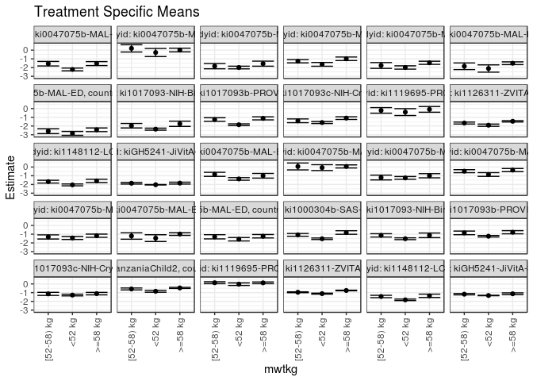

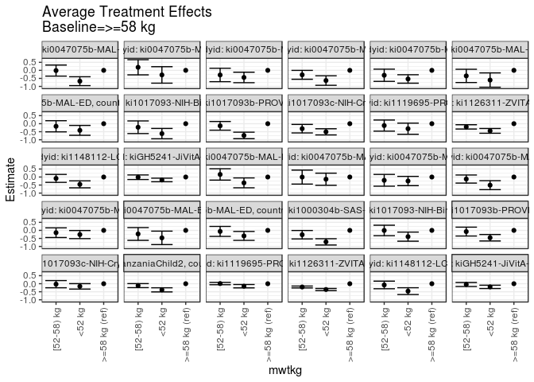

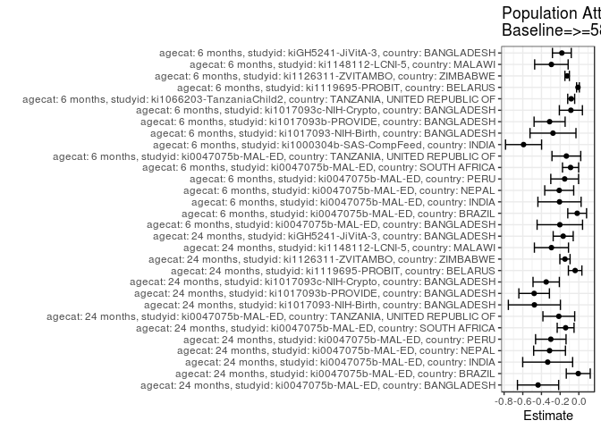

## Results Table

### Parameter: TSM

| agecat | studyid | country | intervention_level | baseline_level | estimate | ci_lower | ci_upper |
| --- | --- | --- | --- | --- | --- | --- | --- |
| 6 months | ki0047075b-MAL-ED | BANGLADESH | >=58 kg | NA | -1.0016403 | -1.2679245 | -0.7353560 |
| 6 months | ki0047075b-MAL-ED | BANGLADESH | <52 kg | NA | -1.3640909 | -1.5137043 | -1.2144776 |
| 6 months | ki0047075b-MAL-ED | BANGLADESH | [52-58) kg | NA | -0.8402339 | -1.0720016 | -0.6084662 |
| 6 months | ki0047075b-MAL-ED | BRAZIL | >=58 kg | NA | 0.0674672 | -0.1096506 | 0.2445851 |
| 6 months | ki0047075b-MAL-ED | BRAZIL | <52 kg | NA | -0.0685112 | -0.4021805 | 0.2651582 |
| 6 months | ki0047075b-MAL-ED | BRAZIL | [52-58) kg | NA | 0.0645711 | -0.3291658 | 0.4583081 |
| 6 months | ki0047075b-MAL-ED | INDIA | >=58 kg | NA | -0.9991287 | -1.2404790 | -0.7577783 |
| 6 months | ki0047075b-MAL-ED | INDIA | <52 kg | NA | -1.2470019 | -1.4027017 | -1.0913022 |
| 6 months | ki0047075b-MAL-ED | INDIA | [52-58) kg | NA | -1.2032419 | -1.4779933 | -0.9284905 |
| 6 months | ki0047075b-MAL-ED | NEPAL | >=58 kg | NA | -0.3516562 | -0.5319782 | -0.1713343 |
| 6 months | ki0047075b-MAL-ED | NEPAL | <52 kg | NA | -0.8584221 | -1.0711599 | -0.6456843 |
| 6 months | ki0047075b-MAL-ED | NEPAL | [52-58) kg | NA | -0.4769509 | -0.6522186 | -0.3016831 |
| 6 months | ki0047075b-MAL-ED | PERU | >=58 kg | NA | -1.1727471 | -1.3552934 | -0.9902007 |
| 6 months | ki0047075b-MAL-ED | PERU | <52 kg | NA | -1.4338091 | -1.6050049 | -1.2626133 |
| 6 months | ki0047075b-MAL-ED | PERU | [52-58) kg | NA | -1.3165078 | -1.5546854 | -1.0783302 |
| 6 months | ki0047075b-MAL-ED | SOUTH AFRICA | >=58 kg | NA | -0.9844667 | -1.1358859 | -0.8330476 |
| 6 months | ki0047075b-MAL-ED | SOUTH AFRICA | <52 kg | NA | -1.4506804 | -1.8384959 | -1.0628650 |
| 6 months | ki0047075b-MAL-ED | SOUTH AFRICA | [52-58) kg | NA | -1.2077124 | -1.5745329 | -0.8408919 |
| 6 months | ki0047075b-MAL-ED | TANZANIA, UNITED REPUBLIC OF | >=58 kg | NA | -1.2353652 | -1.4313977 | -1.0393327 |
| 6 months | ki0047075b-MAL-ED | TANZANIA, UNITED REPUBLIC OF | <52 kg | NA | -1.5799423 | -1.7769400 | -1.3829445 |
| 6 months | ki0047075b-MAL-ED | TANZANIA, UNITED REPUBLIC OF | [52-58) kg | NA | -1.2998801 | -1.5409901 | -1.0587702 |
| 6 months | ki1000304b-SAS-CompFeed | INDIA | >=58 kg | NA | -0.8087737 | -1.0111626 | -0.6063849 |
| 6 months | ki1000304b-SAS-CompFeed | INDIA | <52 kg | NA | -1.5235616 | -1.6099376 | -1.4371857 |
| 6 months | ki1000304b-SAS-CompFeed | INDIA | [52-58) kg | NA | -1.0783960 | -1.2346497 | -0.9221423 |
| 6 months | ki1017093-NIH-Birth | BANGLADESH | >=58 kg | NA | -1.1307618 | -1.3968872 | -0.8646364 |
| 6 months | ki1017093-NIH-Birth | BANGLADESH | <52 kg | NA | -1.5205257 | -1.6234494 | -1.4176020 |
| 6 months | ki1017093-NIH-Birth | BANGLADESH | [52-58) kg | NA | -1.1357460 | -1.3273889 | -0.9441030 |
| 6 months | ki1017093b-PROVIDE | BANGLADESH | >=58 kg | NA | -0.7766815 | -0.9582301 | -0.5951330 |
| 6 months | ki1017093b-PROVIDE | BANGLADESH | <52 kg | NA | -1.2357140 | -1.3213394 | -1.1500886 |
| 6 months | ki1017093b-PROVIDE | BANGLADESH | [52-58) kg | NA | -0.8524800 | -1.0600189 | -0.6449410 |

[output cut: 60 more lines]

### Parameter: E(Y)

| agecat | studyid | country | intervention_level | baseline_level | estimate | ci_lower | ci_upper |
| --- | --- | --- | --- | --- | --- | --- | --- |
| 6 months | ki0047075b-MAL-ED | BANGLADESH | NA | NA | -1.2049931 | -1.3222136 | -1.0877726 |
| 6 months | ki0047075b-MAL-ED | BRAZIL | NA | NA | 0.0497516 | -0.0948051 | 0.1943083 |
| 6 months | ki0047075b-MAL-ED | INDIA | NA | NA | -1.2059574 | -1.3243030 | -1.0876119 |
| 6 months | ki0047075b-MAL-ED | NEPAL | NA | NA | -0.5615819 | -0.6741832 | -0.4489807 |
| 6 months | ki0047075b-MAL-ED | PERU | NA | NA | -1.3241023 | -1.4325083 | -1.2156964 |
| 6 months | ki0047075b-MAL-ED | SOUTH AFRICA | NA | NA | -1.0727443 | -1.2024880 | -0.9430006 |
| 6 months | ki0047075b-MAL-ED | TANZANIA, UNITED REPUBLIC OF | NA | NA | -1.3687449 | -1.4907629 | -1.2467270 |
| 6 months | ki1000304b-SAS-CompFeed | INDIA | NA | NA | -1.4003907 | -1.4819787 | -1.3188027 |
| 6 months | ki1017093-NIH-Birth | BANGLADESH | NA | NA | -1.4073821 | -1.4960598 | -1.3187043 |
| 6 months | ki1017093b-PROVIDE | BANGLADESH | NA | NA | -1.0895301 | -1.1639589 | -1.0151013 |
| 6 months | ki1017093c-NIH-Crypto | BANGLADESH | NA | NA | -1.1986783 | -1.2700937 | -1.1272630 |
| 6 months | ki1066203-TanzaniaChild2 | TANZANIA, UNITED REPUBLIC OF | NA | NA | -0.5424765 | -0.5918460 | -0.4931071 |
| 6 months | ki1119695-PROBIT | BELARUS | NA | NA | 0.1143882 | 0.0212298 | 0.2075466 |
| 6 months | ki1126311-ZVITAMBO | ZIMBABWE | NA | NA | -0.8785195 | -0.9045379 | -0.8525011 |
| 6 months | ki1148112-LCNI-5 | MALAWI | NA | NA | -1.6584707 | -1.7281551 | -1.5887863 |
| 6 months | kiGH5241-JiVitA-3 | BANGLADESH | NA | NA | -1.3134847 | -1.3366230 | -1.2903464 |
| 24 months | ki0047075b-MAL-ED | BANGLADESH | NA | NA | -1.9783962 | -2.1050210 | -1.8517715 |
| 24 months | ki0047075b-MAL-ED | BRAZIL | NA | NA | 0.0059127 | -0.1637934 | 0.1756188 |
| 24 months | ki0047075b-MAL-ED | INDIA | NA | NA | -1.8844690 | -2.0097879 | -1.7591502 |
| 24 months | ki0047075b-MAL-ED | NEPAL | NA | NA | -1.3075877 | -1.4270718 | -1.1881037 |
| 24 months | ki0047075b-MAL-ED | PERU | NA | NA | -1.7524710 | -1.8736426 | -1.6312994 |
| 24 months | ki0047075b-MAL-ED | SOUTH AFRICA | NA | NA | -1.6432229 | -1.7795844 | -1.5068615 |
| 24 months | ki0047075b-MAL-ED | TANZANIA, UNITED REPUBLIC OF | NA | NA | -2.6455607 | -2.7807256 | -2.5103959 |
| 24 months | ki1017093-NIH-Birth | BANGLADESH | NA | NA | -2.2190579 | -2.3217459 | -2.1163699 |
| 24 months | ki1017093b-PROVIDE | BANGLADESH | NA | NA | -1.6002600 | -1.6836163 | -1.5169036 |
| 24 months | ki1017093c-NIH-Crypto | BANGLADESH | NA | NA | -1.4412646 | -1.5249156 | -1.3576135 |
| 24 months | ki1119695-PROBIT | BELARUS | NA | NA | -0.1312742 | -0.4286264 | 0.1660780 |
| 24 months | ki1126311-ZVITAMBO | ZIMBABWE | NA | NA | -1.6070497 | -1.6645093 | -1.5495902 |
| 24 months | ki1148112-LCNI-5 | MALAWI | NA | NA | -1.8854671 | -1.9666281 | -1.8043062 |
| 24 months | kiGH5241-JiVitA-3 | BANGLADESH | NA | NA | -2.0134183 | -2.0410747 | -1.9857620 |

### Parameter: ATE

| agecat | studyid | country | intervention_level | baseline_level | estimate | ci_lower | ci_upper |
| --- | --- | --- | --- | --- | --- | --- | --- |
| 6 months | ki0047075b-MAL-ED | BANGLADESH | >=58 kg | >=58 kg | 0.0000000 | 0.0000000 | 0.0000000 |
| 6 months | ki0047075b-MAL-ED | BANGLADESH | <52 kg | >=58 kg | -0.3624507 | -0.6687271 | -0.0561742 |
| 6 months | ki0047075b-MAL-ED | BANGLADESH | [52-58) kg | >=58 kg | 0.1614064 | -0.1919732 | 0.5147860 |
| 6 months | ki0047075b-MAL-ED | BRAZIL | >=58 kg | >=58 kg | 0.0000000 | 0.0000000 | 0.0000000 |
| 6 months | ki0047075b-MAL-ED | BRAZIL | <52 kg | >=58 kg | -0.1359784 | -0.5124120 | 0.2404553 |
| 6 months | ki0047075b-MAL-ED | BRAZIL | [52-58) kg | >=58 kg | -0.0028961 | -0.4377954 | 0.4320032 |
| 6 months | ki0047075b-MAL-ED | INDIA | >=58 kg | >=58 kg | 0.0000000 | 0.0000000 | 0.0000000 |
| 6 months | ki0047075b-MAL-ED | INDIA | <52 kg | >=58 kg | -0.2478733 | -0.5357215 | 0.0399750 |
| 6 months | ki0047075b-MAL-ED | INDIA | [52-58) kg | >=58 kg | -0.2041132 | -0.5698801 | 0.1616536 |
| 6 months | ki0047075b-MAL-ED | NEPAL | >=58 kg | >=58 kg | 0.0000000 | 0.0000000 | 0.0000000 |
| 6 months | ki0047075b-MAL-ED | NEPAL | <52 kg | >=58 kg | -0.5067659 | -0.7860032 | -0.2275286 |
| 6 months | ki0047075b-MAL-ED | NEPAL | [52-58) kg | >=58 kg | -0.1252947 | -0.3771913 | 0.1266020 |
| 6 months | ki0047075b-MAL-ED | PERU | >=58 kg | >=58 kg | 0.0000000 | 0.0000000 | 0.0000000 |
| 6 months | ki0047075b-MAL-ED | PERU | <52 kg | >=58 kg | -0.2610620 | -0.5124913 | -0.0096327 |
| 6 months | ki0047075b-MAL-ED | PERU | [52-58) kg | >=58 kg | -0.1437607 | -0.4449311 | 0.1574098 |
| 6 months | ki0047075b-MAL-ED | SOUTH AFRICA | >=58 kg | >=58 kg | 0.0000000 | 0.0000000 | 0.0000000 |
| 6 months | ki0047075b-MAL-ED | SOUTH AFRICA | <52 kg | >=58 kg | -0.4662137 | -0.8839815 | -0.0484459 |
| 6 months | ki0047075b-MAL-ED | SOUTH AFRICA | [52-58) kg | >=58 kg | -0.2232456 | -0.6207491 | 0.1742578 |
| 6 months | ki0047075b-MAL-ED | TANZANIA, UNITED REPUBLIC OF | >=58 kg | >=58 kg | 0.0000000 | 0.0000000 | 0.0000000 |
| 6 months | ki0047075b-MAL-ED | TANZANIA, UNITED REPUBLIC OF | <52 kg | >=58 kg | -0.3445771 | -0.6214049 | -0.0677493 |
| 6 months | ki0047075b-MAL-ED | TANZANIA, UNITED REPUBLIC OF | [52-58) kg | >=58 kg | -0.0645150 | -0.3749149 | 0.2458850 |
| 6 months | ki1000304b-SAS-CompFeed | INDIA | >=58 kg | >=58 kg | 0.0000000 | 0.0000000 | 0.0000000 |
| 6 months | ki1000304b-SAS-CompFeed | INDIA | <52 kg | >=58 kg | -0.7147879 | -0.9107112 | -0.5188646 |
| 6 months | ki1000304b-SAS-CompFeed | INDIA | [52-58) kg | >=58 kg | -0.2696223 | -0.5322533 | -0.0069913 |
| 6 months | ki1017093-NIH-Birth | BANGLADESH | >=58 kg | >=58 kg | 0.0000000 | 0.0000000 | 0.0000000 |
| 6 months | ki1017093-NIH-Birth | BANGLADESH | <52 kg | >=58 kg | -0.3897639 | -0.6731149 | -0.1064129 |
| 6 months | ki1017093-NIH-Birth | BANGLADESH | [52-58) kg | >=58 kg | -0.0049841 | -0.3310825 | 0.3211142 |
| 6 months | ki1017093b-PROVIDE | BANGLADESH | >=58 kg | >=58 kg | 0.0000000 | 0.0000000 | 0.0000000 |
| 6 months | ki1017093b-PROVIDE | BANGLADESH | <52 kg | >=58 kg | -0.4590325 | -0.6604761 | -0.2575888 |
| 6 months | ki1017093b-PROVIDE | BANGLADESH | [52-58) kg | >=58 kg | -0.0757984 | -0.3520629 | 0.2004661 |

[output cut: 60 more lines]

### Parameter: PAR

| agecat | studyid | country | intervention_level | baseline_level | estimate | ci_lower | ci_upper |
| --- | --- | --- | --- | --- | --- | --- | --- |
| 6 months | ki0047075b-MAL-ED | BANGLADESH | >=58 kg | NA | -0.2033528 | -0.4467157 | 0.0400101 |
| 6 months | ki0047075b-MAL-ED | BRAZIL | >=58 kg | NA | -0.0177156 | -0.1182254 | 0.0827941 |
| 6 months | ki0047075b-MAL-ED | INDIA | >=58 kg | NA | -0.2068288 | -0.4381419 | 0.0244843 |
| 6 months | ki0047075b-MAL-ED | NEPAL | >=58 kg | NA | -0.2099257 | -0.3649473 | -0.0549041 |
| 6 months | ki0047075b-MAL-ED | PERU | >=58 kg | NA | -0.1513553 | -0.3000980 | -0.0026125 |
| 6 months | ki0047075b-MAL-ED | SOUTH AFRICA | >=58 kg | NA | -0.0882776 | -0.1747376 | -0.0018175 |
| 6 months | ki0047075b-MAL-ED | TANZANIA, UNITED REPUBLIC OF | >=58 kg | NA | -0.1333798 | -0.2874614 | 0.0207019 |
| 6 months | ki1000304b-SAS-CompFeed | INDIA | >=58 kg | NA | -0.5916169 | -0.7845636 | -0.3986703 |
| 6 months | ki1017093-NIH-Birth | BANGLADESH | >=58 kg | NA | -0.2766203 | -0.5226357 | -0.0306048 |
| 6 months | ki1017093b-PROVIDE | BANGLADESH | >=58 kg | NA | -0.3128486 | -0.4790541 | -0.1466431 |
| 6 months | ki1017093c-NIH-Crypto | BANGLADESH | >=58 kg | NA | -0.0849991 | -0.2084543 | 0.0384561 |
| 6 months | ki1066203-TanzaniaChild2 | TANZANIA, UNITED REPUBLIC OF | >=58 kg | NA | -0.0816396 | -0.1188959 | -0.0443833 |
| 6 months | ki1119695-PROBIT | BELARUS | >=58 kg | NA | -0.0090624 | -0.0238252 | 0.0057003 |
| 6 months | ki1126311-ZVITAMBO | ZIMBABWE | >=58 kg | NA | -0.1249291 | -0.1488050 | -0.1010533 |
| 6 months | ki1148112-LCNI-5 | MALAWI | >=58 kg | NA | -0.2936295 | -0.4727934 | -0.1144655 |
| 6 months | kiGH5241-JiVitA-3 | BANGLADESH | >=58 kg | NA | -0.1816243 | -0.2823364 | -0.0809122 |
| 24 months | ki0047075b-MAL-ED | BANGLADESH | >=58 kg | NA | -0.4364956 | -0.6571454 | -0.2158457 |
| 24 months | ki0047075b-MAL-ED | BRAZIL | >=58 kg | NA | -0.0060745 | -0.1342977 | 0.1221488 |
| 24 months | ki0047075b-MAL-ED | INDIA | >=58 kg | NA | -0.3335082 | -0.6008552 | -0.0661612 |
| 24 months | ki0047075b-MAL-ED | NEPAL | >=58 kg | NA | -0.3133628 | -0.4835399 | -0.1431857 |
| 24 months | ki0047075b-MAL-ED | PERU | >=58 kg | NA | -0.2998867 | -0.4630111 | -0.1367622 |
| 24 months | ki0047075b-MAL-ED | SOUTH AFRICA | >=58 kg | NA | -0.1412820 | -0.2315103 | -0.0510537 |
| 24 months | ki0047075b-MAL-ED | TANZANIA, UNITED REPUBLIC OF | >=58 kg | NA | -0.2143245 | -0.3843868 | -0.0442622 |
| 24 months | ki1017093-NIH-Birth | BANGLADESH | >=58 kg | NA | -0.4757975 | -0.7545911 | -0.1970039 |
| 24 months | ki1017093b-PROVIDE | BANGLADESH | >=58 kg | NA | -0.4783846 | -0.6419525 | -0.3148166 |
| 24 months | ki1017093c-NIH-Crypto | BANGLADESH | >=58 kg | NA | -0.3493718 | -0.4903864 | -0.2083572 |
| 24 months | ki1119695-PROBIT | BELARUS | >=58 kg | NA | -0.0394480 | -0.1117374 | 0.0328414 |
| 24 months | ki1126311-ZVITAMBO | ZIMBABWE | >=58 kg | NA | -0.1482867 | -0.2029191 | -0.0936544 |
| 24 months | ki1148112-LCNI-5 | MALAWI | >=58 kg | NA | -0.2931133 | -0.4756177 | -0.1106089 |
| 24 months | kiGH5241-JiVitA-3 | BANGLADESH | >=58 kg | NA | -0.1673628 | -0.2746386 | -0.0600870 |